# UK-BankSentiment-Analyzer

Sunpreet Singh

7/9/2017

# Sentiment-Analyzer(Framing)

As I am working for a UK client-Santander Bank, I am interested to know what are people’s sentiments towards its services. Also, I would like to compare that feedback against other top 3 Uk banks namely Lloyds Banking Group, HSBC, and Barclays.

# Sentiment-Analyzer(Acquiring)

To fetch the reviews we can look at below places

1. Twitter - Twitter is a great source of real time social networking data. There is an R package called twitteR which can help authenticate the handshake. We would need to have an account with a valid phone number and create a personal app on apps.twitter.com to get going. Having said that, the limit of 144 characters per tweet doesn’t give much of customer insight.
2. Facebook - Again a great source, but we will be avoiding this as we are mainly looking for a site like amazon where reviews are posted.
3. Trustpilot - Although this site is relatively new, but it captures the reviews for all these four banks nicely. This seems like a great starting point

```r
#Loading the libraries
library(rvest)
library(pbapply)
library(tm)
```

```r
library(wordcloud)
library(stringr)
library(SnowballC)

Pages = 1:38
# URLs for web scraping
Santander_all_urls =paste0('https://www.trustpilot.com/review/www.santander.co.uk?page=',Pages[1:37])
Lloyds_all_urls = paste0('https://www.trustpilot.com/review/www.clicksafe.lloydstsb.com?page=',Pages[1:10])
Hsbc_all_urls =paste0('https://www.trustpilot.com/review/www.hsbc.co.uk?page=',Pages[1:38])
Barclays_all_urls=paste0('https://www.trustpilot.com/review/www.barclays.co.uk?page=',Pages[1:29])

# Function to retrieve the data
get_data = function(url_input){

  x= read_html(url_input)
  y = x %>% html_nodes(".review-body") %>%
     html_text()
  return (y)
  Sys.sleep(5)

}
```

Get review data for all four banks by invoking get_data

```r
#Santander
Santander_reviews = pblapply(Santander_all_urls,get_data)
Santander_reviews =unlist(Santander_reviews)
Santander_reviews= gsub("[\r\n]", "", Santander_reviews)


#Lloyds

Lloyds_reviews = pblapply(Lloyds_all_urls,get_data)
Lloyds_reviews =unlist(Lloyds_reviews)
LLyods_reviews = gsub("[\r\n]", "", Lloyds_reviews)

#HSBC
Hsbc_reviews = pblapply(Hsbc_all_urls,get_data)
Hsbc_reviews =unlist(Hsbc_reviews)
Hsbc_reviews = gsub("[\r\n]", "", Hsbc_reviews)


#Barclays
Barclays_reviews=pblapply(Barclays_all_urls,get_data)
Barclays_reviews=unlist(Barclays_reviews)
Barclays_reviews = gsub("[\r\n]", "", Barclays_reviews)
```

Now we have everything to start our sentiment analyzer. Saving the above result into text documents.

```r
Santander_fileConn =file("Santander_Reviews.txt")
writeLines(Santander_reviews,Santander_fileConn)

Lloyds_fileConn =file("Lloyds_Reviews.txt")
writeLines(Lloyds_reviews,Lloyds_fileConn)

Hsbc_fileConn =file("Hsbc_Reviews.txt")
writeLines(Hsbc_reviews,Hsbc_fileConn)

Barclays_fileConn =file("Barclays_Reviews.txt")
writeLines(Barclays_reviews,Barclays_fileConn)

#Closing file connection
close.connection(Santander_fileConn)
close.connection(Lloyds_fileConn)
close.connection(Hsbc_fileConn)
close.connection(Barclays_fileConn)
```

Loading the data back again. First we will try only for Santander bank to see what people have reported

```r
filelist = c("Santander_Reviews.txt","Lloyds_Reviews.txt","Hsbc_Reviews.txt","Barclays_Reviews.txt")

#Reading the data back
Santander_reviews =lapply(filelist[1],FUN =readLines)
Lloyds_reviews =lapply(filelist[2],FUN =readLines)
Hsbc_reviews =lapply(filelist[3],FUN =readLines)
Barclays_reviews=lapply(filelist[4],FUN =readLines)

# Loads the psotive and negative wordlist
positive = scan('Positive.txt',what='character',comment.char = ';')
negative = scan('Negative.txt',what='character',comment.char = ';')

Santander_reviews[[1]][1:5]
```

```
## [1] "                From the beginning we have had endless problems!Avoid! Avoid! Avoid!            "
## [2] "                Just had two different complaints about their service looked into by Santander. The first one took a few weeks to investigate (which was quite understandable), the second one was dealt with over the telephone. Both complaints were upheld and Santander agreed they had fallen s…
## [3] "                After many phone calls I finally managed access to my online account.Only they then closed that,  insisting I go to a branch. Photo Id etc...The customer service is appalling,  If you can't run an online and telephone banking service without STUPID 'security' controls - it is…
## [4] "                very bad service            "
## [5] "                Got through to someone quickly rather than an automated system, wanted to cancel a direct debit and took under two minutes. Amazing customer experience.            "
```

# Sentiment-Analyzer(Refine)

We can see that the data is not clean. Infact we would like to perform below actions to clean our reviews

1. Remove punctuation.
2. Remove numbers
3. Remove Stopwords
4. Stripout remaning Whitespaces

```r
# Function to clean the data

clean_data = function (reviews){
  Bank_reviews =unlist(reviews)

#Convert into lower case
  Bank_reviews =tolower(Bank_reviews)

# Removing the stop words
  Bank_reviews=removeWords(Bank_reviews,c(stopwords("english"),"via","will","got","account","bank","banking"))

#Remove the punctuations
  Bank_reviews =gsub(pattern = "\\W",replace=" ",Bank_reviews)


#Removing Numbers
 Bank_reviews =gsub(pattern = "\\d",replace=" ",Bank_reviews)

#Remove single letter words
 Bank_reviews=gsub(pattern ="\\b[A-z]\\b{1}",replace=" ",Bank_reviews)

#Stripping the whitespace
 Bank_reviews =stripWhitespace(Bank_reviews)

 return(Bank_reviews)
}
```

# Sentiment-Analyzer(Transform)

Creating a Corpus and TermDocument matrix of review data

```r
# Creating a function for creating a corpus
WordCorpus = function(reviews){

  Bank_reviews_Corpus = Corpus(VectorSource(reviews))

# Stemming the corpus so that words like bank,banking will be coverted into root word bank
#  Bank_reviews_Corpus_Copy = Bank_reviews_Corpus
#  Bank_reviews_Corpus = tm_map(Bank_reviews_Corpus,stemDocument)
#  Bank_reviews_Corpus = tm_map(Bank_reviews_Corpus,stemCompletion,dictionary=Bank_reviews_Corpus_Copy)

  return (Bank_reviews_Corpus)

}

TDM = function(corpus,freq){

  tdm = TermDocumentMatrix(corpus)
  tdm.matrix = as.matrix(tdm)

  Term_frequency = rowSums(tdm.matrix)
  Term_frequency = subset(Term_frequency, Term_frequency>=freq)
  return(Term_frequency)

}
```

# Sentiment-Analyzer(Explore)

Let us figure out what review data we have in store

```r
# Cleaning the data

Santander_reviews = clean_data(Santander_reviews)
Santander_reviews[1:5]
```

```
## [1] " beginning endless problems avoid avoid avoid "
## [2] " just two different complaints service looked santander first one took weeks investigate quite understandable second one dealt telephone complaints upheld santander agreed fallen short service providing now refunded losses incurred mistake credited way apology distress inconvenience caused w…
## [3] " many phone calls finally managed access online closed insisting go branch photo id etc customer service appalling run online telephone service without stupid security controls time leave "
## [4] " bad service "
## [5] " someone quickly rather automated system wanted cancel direct debit took two minutes amazing customer experience "
```

The data has been cleansed now. lets create a WordCloud and TermDocument matrix for santander

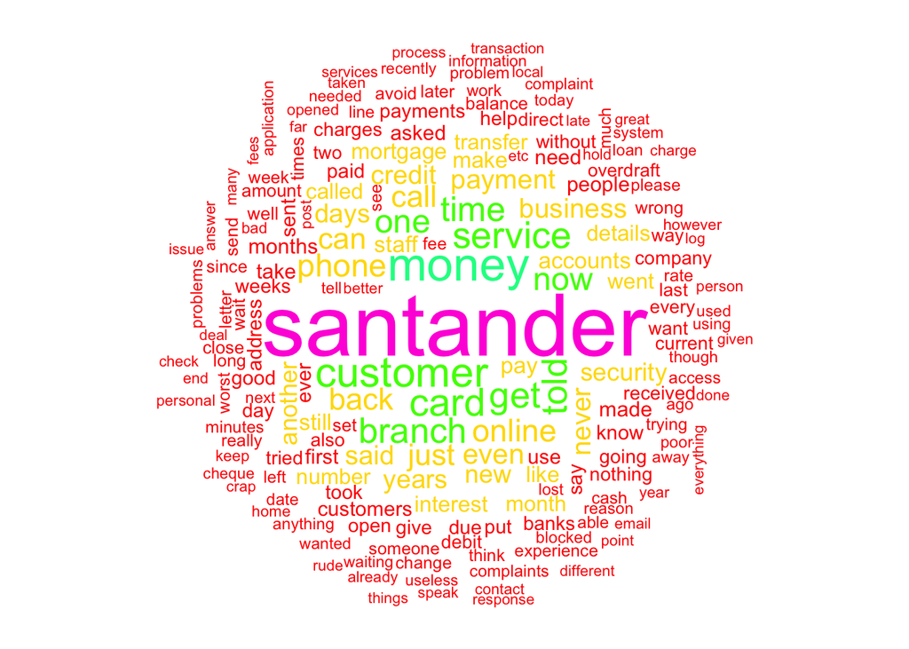

```r
Santander_Corpus = WordCorpus(Santander_reviews)
wordcloud(Santander_Corpus,random.order = FALSE,min.freq = 50,colors = rainbow(7))
```

Let’s see in terms of barplot the frequency of top words

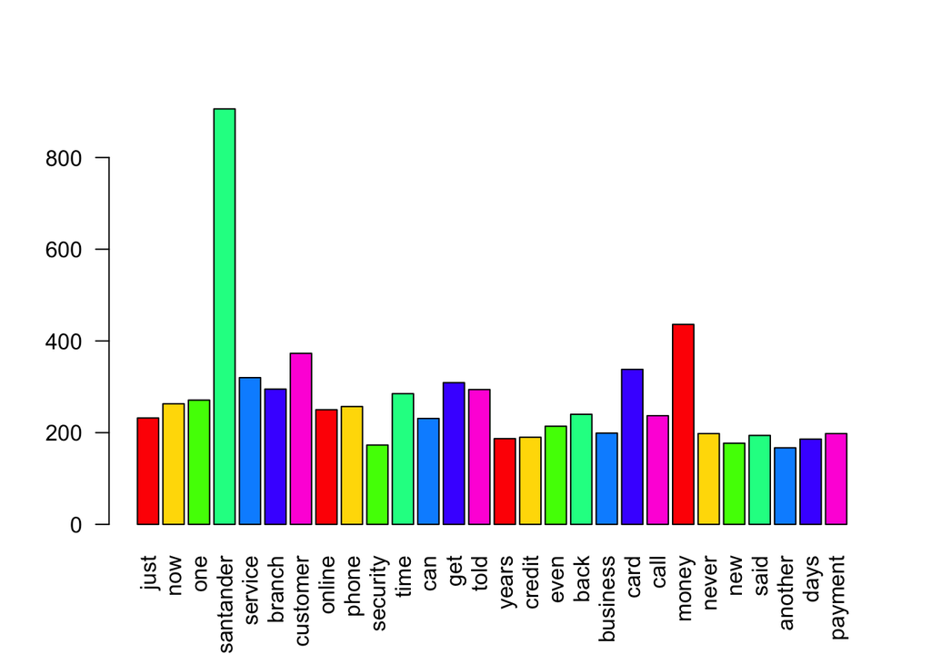

```r
Santander_term_freq = TDM(Santander_Corpus,150)
barplot(Santander_term_freq,las=2,col=rainbow(7))
```

As we can see, the word santander itself feature more than 800 times which is expected as the reviews are about Santander Uk. Let us now do a similar exercise for all other banks

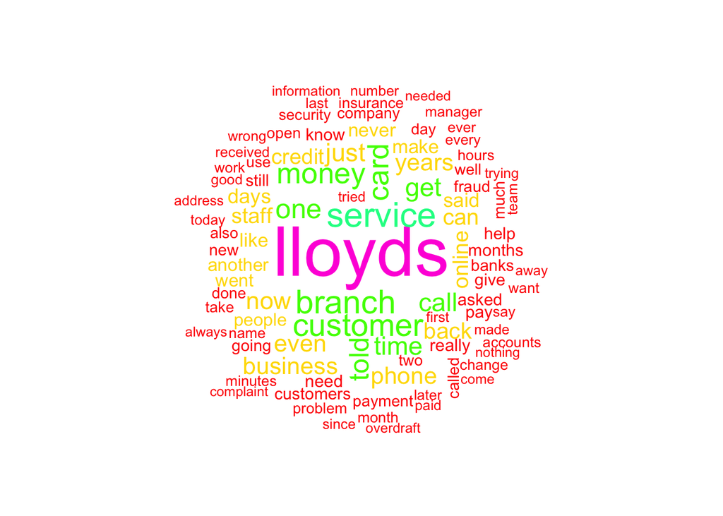

```r
# Lloyds
Lloyds_reviews =clean_data(Lloyds_reviews)
Llyods_Corpus = WordCorpus(Lloyds_reviews)
wordcloud(Llyods_Corpus,random.order = FALSE,min.freq = 50,colors = rainbow(7))
```

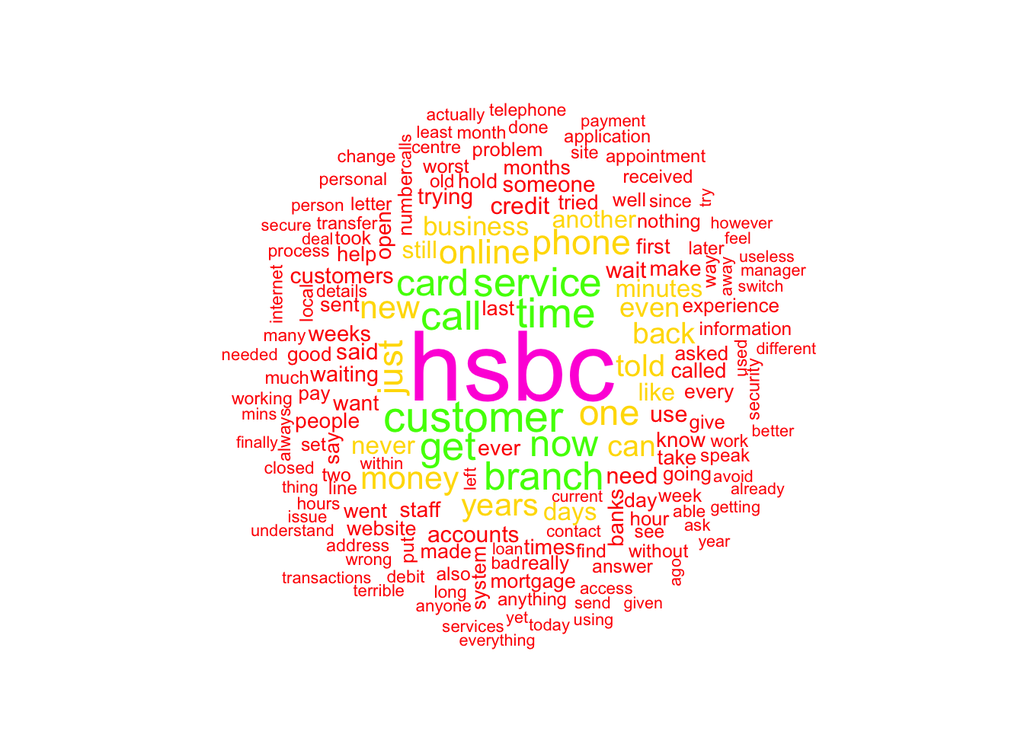

```r
#HSBC
Hsbc_reviews =clean_data(Hsbc_reviews)
Hsbc_Corpus = WordCorpus(Hsbc_reviews)
wordcloud(Hsbc_Corpus,random.order = FALSE,min.freq = 50,colors = rainbow(7))
```

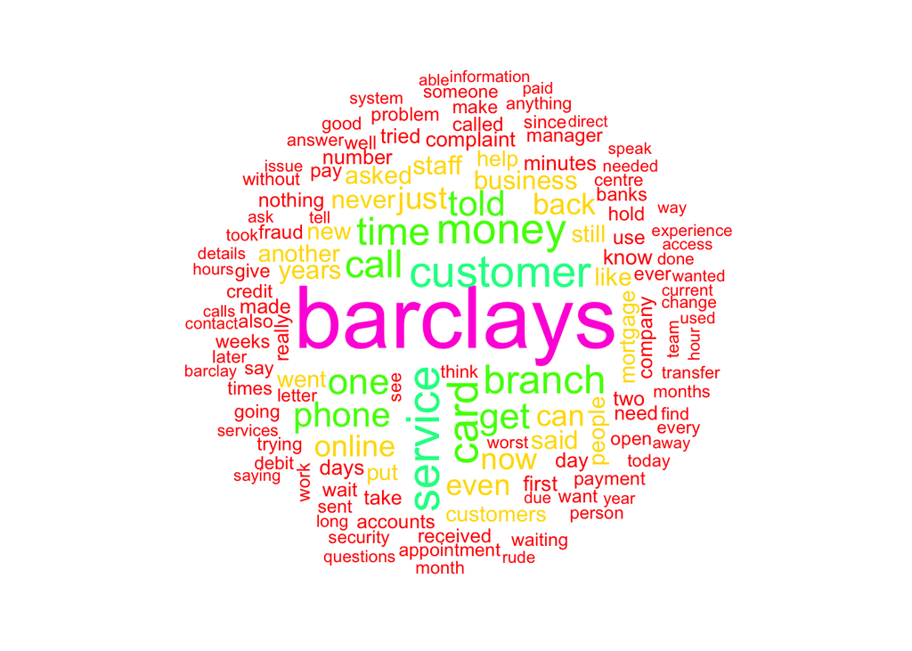

```r
#HSBC
Barclays_reviews =clean_data(Barclays_reviews)
Barclays_Corpus = WordCorpus(Barclays_reviews)
wordcloud(Barclays_Corpus,random.order = FALSE,min.freq = 50,colors = rainbow(7))
```

# Sentiment-Analyzer(Interactive Visualization)

The above wordcloud and frequency histogram can also be depicted in an interactive dashboard

I have prepared a similar dashboard under shinyapps and you can check the same at

### Click below link

**[UK Bank Sentiment Analyses](https://sunpreet.shinyapps.io/uk_banks/)**

Let’s us try to do some more interactive visualization for sentiment review

```r
# Fuction for creating review dataframe
Sentiment_dataframe = function(reviews,name)

{
  Bank_BOW= str_split(reviews,pattern="\\s+")
  Bank_review_score= unlist(lapply(Bank_BOW,function(x){sum(!is.na(match(x,positive)))-
                                                         sum(!is.na(match(x,negative)))}))
  Bank_review_word_count = unlist(lapply(Bank_BOW,FUN = length))
  Bank_name = as.factor(toupper(name))
  Bank_review_df = data.frame(Bank_review_score,Bank_review_word_count,Bank_name)
  return(Bank_review_df)
}


Banks_reviews =data.frame()
Banks_reviews = rbind(Sentiment_dataframe(Santander_reviews,"Santander"),Banks_reviews)
Banks_reviews = rbind(Sentiment_dataframe(Lloyds_reviews,"Lloyds"),Banks_reviews)
Banks_reviews = rbind(Sentiment_dataframe(Hsbc_reviews,"Hsbc"),Banks_reviews)
Banks_reviews = rbind(Sentiment_dataframe(Barclays_reviews,"Barclays"),Banks_reviews)
colnames(Banks_reviews) = c("SCORE","REVIEW_LENGTH","BANK")
head(Banks_reviews)
```

```
##   SCORE REVIEW_LENGTH     BANK
## 1    -3            21 BARCLAYS
## 2    -4            68 BARCLAYS
## 3    -6            45 BARCLAYS
## 4    -5            27 BARCLAYS
## 5     1            78 BARCLAYS
## 6    -1            12 BARCLAYS
```

```r
library(crosstalk)
library(d3scatter)

shared_bank <- SharedData$new(Banks_reviews)

bscols(
  list(
    filter_checkbox("BANK", "Bank", shared_bank, ~BANK, inline = TRUE),
    filter_slider("SCORE", "Score", shared_bank, ~SCORE, width = "100%")
  ),
  d3scatter(shared_bank,~SCORE,~REVIEW_LENGTH,~BANK, width="100%", height=300)
)
```

Bank

BARCLAYS HSBC LLOYDS SANTANDER

Score

[interactive chart not shown]

#Sentiment-Analyzer(Communicate)

It is entirely fair to say that there is a lot of negativity for all four banks as the sentiment score is mostly negative. Perhaps it is the right time for these banks to look into social media and try rectifying few of the issues the customers face on daily bases.